# Sklearn

```python
from sklearn.linear_model import (LinearRegression, Ridge, Lasso,
                                    LogisticRegression)
import pandas as pd
import matplotlib.pyplot as plt
import seaborn as sns
import numpy as np
%matplotlib inline
```

```python
names = []
with open('communities.names') as inf:
    for row in inf:
        if row.startswith('@attribute'):
            col = row.strip().split()[1]
            names.append(col)
```

```python
!head communities.names
```

```
Title: Communities and Crime

Abstract: Communities within the United States. The data combines socio-economic data
from the 1990 US Census, law enforcement data from the 1990 US LEMAS survey, and crime
data from the 1995 FBI UCR.

-----------------------------------------------------------------------------------------

Data Set Characteristics:  Multivariate
Attribute Characteristics: Real
```

```python
df = pd.read_csv('communities.data', names=names)
```

```python
df.head()
```

|  | state | county | community | communityname | fold | population | householdsize | racepctblack | racePctWhite | racePctAsian | ... | LandArea | PopDens | PctUsePubTrans | PolicCars | PolicOperBudg | LemasPctPolicOnPatr | LemasGangUnitDeploy | LemasPctOfficDrugUn | PolicBudgPerPop | ViolentCrimesPerPop |
| --- | --- | --- | --- | --- | --- | --- | --- | --- | --- | --- | --- | --- | --- | --- | --- | --- | --- | --- | --- | --- | --- |
| 0 | 8 | NaN | NaN | Lakewoodcity | 1 | 0.19 | 0.33 | 0.02 | 0.90 | 0.12 | ... | 0.12 | 0.26 | 0.20 | 0.06 | 0.04 | 0.9 | 0.5 | 0.32 | 0.14 | 0.20 |
| 1 | 53 | NaN | NaN | Tukwilacity | 1 | 0.00 | 0.16 | 0.12 | 0.74 | 0.45 | ... | 0.02 | 0.12 | 0.45 | NaN | NaN | NaN | NaN | 0.00 | NaN | 0.67 |
| 2 | 24 | NaN | NaN | Aberdeentown | 1 | 0.00 | 0.42 | 0.49 | 0.56 | 0.17 | ... | 0.01 | 0.21 | 0.02 | NaN | NaN | NaN | NaN | 0.00 | NaN | 0.43 |
| 3 | 34 | 5.0 | 81440.0 | Willingborotownship | 1 | 0.04 | 0.77 | 1.00 | 0.08 | 0.12 | ... | 0.02 | 0.39 | 0.28 | NaN | NaN | NaN | NaN | 0.00 | NaN | 0.12 |
| 4 | 42 | 95.0 | 6096.0 | Bethlehemtownship | 1 | 0.01 | 0.55 | 0.02 | 0.95 | 0.09 | ... | 0.04 | 0.09 | 0.02 | NaN | NaN | NaN | NaN | 0.00 | NaN | 0.03 |

5 rows × 128 columns

```python
df = df.replace(to_replace='?', value=np.nan)
```

```python
df.info()
```

```
<class 'pandas.core.frame.DataFrame'>
RangeIndex: 1994 entries, 0 to 1993
Columns: 128 entries, state to ViolentCrimesPerPop
dtypes: float64(125), int64(2), object(1)
memory usage: 1.9+ MB
```

```python
df.dtypes
```

```
state                    int64
county                 float64
community              float64
communityname           object
fold                     int64
                        ...
LemasPctPolicOnPatr    float64
LemasGangUnitDeploy    float64
LemasPctOfficDrugUn    float64
PolicBudgPerPop        float64
ViolentCrimesPerPop    float64
Length: 128, dtype: object
```

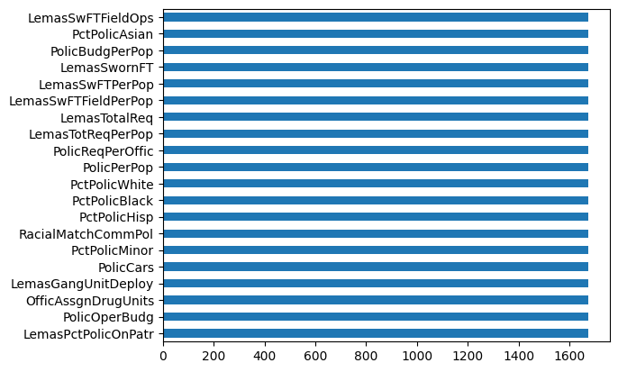

```python
df.isna().sum().sort_values()[-20:].plot.barh()
```

### Удалим все колонки, кроме признаков непрерывного типа

```python
cols_drop = ['state', 'communityname', 'fold']
for col, nans in list(df.isna().sum().items()):
    print(col, nans)
    if nans > 0:
        cols_drop.append(col)
```

```
state 0
county 1174
community 1177
communityname 0
fold 0
population 0
householdsize 0
racepctblack 0
racePctWhite 0
racePctAsian 0
racePctHisp 0
agePct12t21 0
agePct12t29 0
agePct16t24 0
agePct65up 0
numbUrban 0
pctUrban 0
medIncome 0
pctWWage 0
pctWFarmSelf 0
pctWInvInc 0
pctWSocSec 0
pctWPubAsst 0
pctWRetire 0
medFamInc 0
perCapInc 0
whitePerCap 0
blackPerCap 0
indianPerCap 0
AsianPerCap 0
OtherPerCap 1
HispPerCap 0
NumUnderPov 0
PctPopUnderPov 0
PctLess9thGrade 0
PctNotHSGrad 0
PctBSorMore 0
PctUnemployed 0
PctEmploy 0
PctEmplManu 0
```

[output cut: 73 more lines]

```
PctPolicAsian 1675
PctPolicMinor 1675
OfficAssgnDrugUnits 1675
NumKindsDrugsSeiz 1675
PolicAveOTWorked 1675
LandArea 0
PopDens 0
PctUsePubTrans 0
PolicCars 1675
PolicOperBudg 1675
LemasPctPolicOnPatr 1675
LemasGangUnitDeploy 1675
LemasPctOfficDrugUn 0
PolicBudgPerPop 1675
ViolentCrimesPerPop 0
```

```python
len(cols_drop), cols_drop
```

```
(28,
 ['state',
  'communityname',
  'fold',
  'county',
  'community',
  'OtherPerCap',
  'LemasSwornFT',
  'LemasSwFTPerPop',
  'LemasSwFTFieldOps',
  'LemasSwFTFieldPerPop',
  'LemasTotalReq',
  'LemasTotReqPerPop',
  'PolicReqPerOffic',
  'PolicPerPop',
  'RacialMatchCommPol',
  'PctPolicWhite',
  'PctPolicBlack',
  'PctPolicHisp',
  'PctPolicAsian',
  'PctPolicMinor',
  'OfficAssgnDrugUnits',
  'NumKindsDrugsSeiz',
  'PolicAveOTWorked',
  'PolicCars',
  'PolicOperBudg',
  'LemasPctPolicOnPatr',
  'LemasGangUnitDeploy',
  'PolicBudgPerPop'])
```

```python
df_prep = df.drop(columns=cols_drop)
```

```python
df_prep
```

|  | population | householdsize | racepctblack | racePctWhite | racePctAsian | racePctHisp | agePct12t21 | agePct12t29 | agePct16t24 | agePct65up | ... | PctForeignBorn | PctBornSameState | PctSameHouse85 | PctSameCity85 | PctSameState85 | LandArea | PopDens | PctUsePubTrans | LemasPctOfficDrugUn | ViolentCrimesPerPop |
| --- | --- | --- | --- | --- | --- | --- | --- | --- | --- | --- | --- | --- | --- | --- | --- | --- | --- | --- | --- | --- | --- |
| 0 | 0.19 | 0.33 | 0.02 | 0.90 | 0.12 | 0.17 | 0.34 | 0.47 | 0.29 | 0.32 | ... | 0.12 | 0.42 | 0.50 | 0.51 | 0.64 | 0.12 | 0.26 | 0.20 | 0.32 | 0.20 |
| 1 | 0.00 | 0.16 | 0.12 | 0.74 | 0.45 | 0.07 | 0.26 | 0.59 | 0.35 | 0.27 | ... | 0.21 | 0.50 | 0.34 | 0.60 | 0.52 | 0.02 | 0.12 | 0.45 | 0.00 | 0.67 |
| 2 | 0.00 | 0.42 | 0.49 | 0.56 | 0.17 | 0.04 | 0.39 | 0.47 | 0.28 | 0.32 | ... | 0.14 | 0.49 | 0.54 | 0.67 | 0.56 | 0.01 | 0.21 | 0.02 | 0.00 | 0.43 |
| 3 | 0.04 | 0.77 | 1.00 | 0.08 | 0.12 | 0.10 | 0.51 | 0.50 | 0.34 | 0.21 | ... | 0.19 | 0.30 | 0.73 | 0.64 | 0.65 | 0.02 | 0.39 | 0.28 | 0.00 | 0.12 |
| 4 | 0.01 | 0.55 | 0.02 | 0.95 | 0.09 | 0.05 | 0.38 | 0.38 | 0.23 | 0.36 | ... | 0.11 | 0.72 | 0.64 | 0.61 | 0.53 | 0.04 | 0.09 | 0.02 | 0.00 | 0.03 |
| ... | ... | ... | ... | ... | ... | ... | ... | ... | ... | ... | ... | ... | ... | ... | ... | ... | ... | ... | ... | ... | ... |
| 1989 | 0.01 | 0.40 | 0.10 | 0.87 | 0.12 | 0.16 | 0.43 | 0.51 | 0.35 | 0.30 | ... | 0.22 | 0.28 | 0.34 | 0.48 | 0.39 | 0.01 | 0.28 | 0.05 | 0.00 | 0.09 |
| 1990 | 0.05 | 0.96 | 0.46 | 0.28 | 0.83 | 0.32 | 0.69 | 0.86 | 0.73 | 0.14 | ... | 0.53 | 0.25 | 0.17 | 0.10 | 0.00 | 0.02 | 0.37 | 0.20 | 0.00 | 0.45 |
| 1991 | 0.16 | 0.37 | 0.25 | 0.69 | 0.04 | 0.25 | 0.35 | 0.50 | 0.31 | 0.54 | ... | 0.25 | 0.68 | 0.61 | 0.79 | 0.76 | 0.08 | 0.32 | 0.18 | 0.91 | 0.23 |
| 1992 | 0.08 | 0.51 | 0.06 | 0.87 | 0.22 | 0.10 | 0.58 | 0.74 | 0.63 | 0.41 | ... | 0.45 | 0.64 | 0.54 | 0.59 | 0.52 | 0.03 | 0.38 | 0.33 | 0.22 | 0.19 |
| 1993 | 0.20 | 0.78 | 0.14 | 0.46 | 0.24 | 0.77 | 0.50 | 0.62 | 0.40 | 0.17 | ... | 0.68 | 0.50 | 0.34 | 0.35 | 0.68 | 0.11 | 0.30 | 0.05 | 1.00 | 0.48 |

1994 rows × 100 columns

```python
df_prep.shape
```

```
(1994, 100)
```

```python
X = df_prep.values[:, :-1]
y = df_prep.values[:, -1]
```

## Борьба с переобучением

Самый основной способ - разделение выборки на обучающую и тестовую

```python
from sklearn.model_selection import  train_test_split
```

```python
X.shape, y.shape
```

```
((1994, 99), (1994,))
```

```python
X_train, X_test, y_train ,y_test = train_test_split(X, y,
                                                 test_size=0.33,
                                                 random_state=42,
                                                 shuffle = True)
```

```python
X_train.shape, X_test.shape
```

```
((1335, 99), (659, 99))
```

```python
y_train
```

```
array([0.02, 0.49, 0.01, ..., 0.13, 0.37, 0.17])
```

train_data, test_data = model_selection.train_test_split(data)

### Распределение значений целевых параметров выглядит схожим

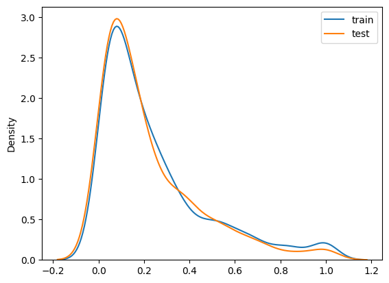

```python
sns.kdeplot(y_train, label='train')
sns.kdeplot(y_test, label='test')
plt.legend()
plt.show()
```

## Обучаем линейную регрессию

### Сначала создаем объект класса "Линейная регрессия"

```python
lr = LinearRegression()
```

### Функция fit(X, y) - подбирает оптимальные веса коэффициентов регрессии согласно данным в матрице $X$, с целью минимизировать квадратичное отклонение от вектора таргета $y$

```python
lr.fit(X_train, y_train)
```

```
LinearRegression()
```

### Посмотрим на коэффициенты и свободный член

```python
lr.coef_
```

```
array([ 6.21628904e-02,  3.39704112e-03,  2.03897088e-01, -6.60520402e-02,
       -4.22206903e-02, -1.30372970e-02,  4.75381796e-02, -2.37862163e-01,
        2.54215894e-04,  7.20966856e-02, -2.15453488e-01,  4.59015715e-02,
       -4.80280459e-02, -1.71188144e-01,  4.64266990e-02, -2.29978526e-01,
        4.94477572e-02, -6.23769582e-02, -6.34376985e-02,  2.35455956e-01,
        2.08348993e-01, -4.41320833e-01, -1.23750283e-02, -3.18566222e-02,
        3.45880746e-02,  5.83329222e-02,  2.54735235e-01, -1.90211524e-01,
       -1.93650781e-01,  1.29209054e-01,  5.19451631e-03, -5.34032036e-02,
        1.78913978e-01, -7.25125875e-02, -1.45326510e-02,  8.81224991e-02,
        1.35810071e-01,  4.47299883e-01,  1.96629061e-01,  2.07592334e-01,
       -5.48978996e-01,  5.36452459e-02, -1.68190246e-01, -3.36783086e-02,
       -1.48675480e-01, -3.00492545e-02,  3.65004087e-02, -1.71874511e-01,
       -2.80914281e-01,  1.13563575e-01, -1.25064969e-01,  1.14270772e-01,
       -1.19180271e-01, -5.76544569e-03,  1.30995690e-02, -1.51518110e-01,
        1.12373076e-01,  3.65178748e-01, -2.85848456e-01, -1.33099508e-01,
       -1.76341343e-01,  5.01934972e-02, -2.42500931e-01,  4.79232775e-01,
       -1.36935703e-01, -1.71194120e-01, -5.38019076e-01,  2.00491650e-01,
        9.28955440e-02,  1.41789926e-02,  1.63700012e-01, -4.55041154e-02,
        4.19711923e-01,  5.42057649e-02, -6.90130839e-02,  1.58897747e-02,
        5.84328287e-02,  5.91319427e-04, -5.54829946e-02, -2.20812736e-01,
        1.99712179e-01, -2.82179510e-01,  7.61484240e-02, -7.19556854e-02,
        3.20004890e-01,  7.22424016e-02, -3.04031431e-02, -1.32180606e-01,
        8.47857016e-02,  2.51445176e-01,  1.02003046e-01,  6.76992412e-02,
        2.28475411e-02,  4.57290223e-03, -1.76407193e-03,  1.27536867e-02,
        2.25572264e-03, -1.26015662e-02,  1.76379559e-02])
```

```python
lr.intercept_
```

```
0.6290116928001219
```

```python
coef_df = pd.DataFrame(list(zip(df_prep.columns[:-1], lr.coef_)),
                       columns=['col', 'weight']
                      )\
.sort_values('weight', ascending=False)
coef_df
```

|  | col | weight |
| --- | --- | --- |
| 63 | PersPerOccupHous | 0.479233 |
| 37 | MalePctDivorce | 0.447300 |
| 72 | PctHousOwnOcc | 0.419712 |
| 57 | PctRecImmig8 | 0.365179 |
| 84 | MedRent | 0.320005 |
| ... | ... | ... |
| 81 | RentLowQ | -0.282180 |
| 58 | PctRecImmig10 | -0.285848 |
| 21 | whitePerCap | -0.441321 |
| 66 | PctPersOwnOccup | -0.538019 |
| 40 | TotalPctDiv | -0.548979 |

99 rows × 2 columns

```python
coefs_arr = np.array(sorted(list(zip(df_prep.columns[:-1], lr.coef_)),
                            key=lambda x: -x[1]))
```

```python
for nat in [i for i in df_prep.columns if 'PerCap' in i]:
    display(coef_df.query(f"col=='{nat}'"))
```

|  | col | weight |
| --- | --- | --- |
| 21 | whitePerCap | -0.441321 |

|  | col | weight |
| --- | --- | --- |
| 22 | blackPerCap | -0.012375 |

|  | col | weight |
| --- | --- | --- |
| 23 | indianPerCap | -0.031857 |

|  | col | weight |
| --- | --- | --- |
| 24 | AsianPerCap | 0.034588 |

|  | col | weight |
| --- | --- | --- |
| 25 | HispPerCap | 0.058333 |

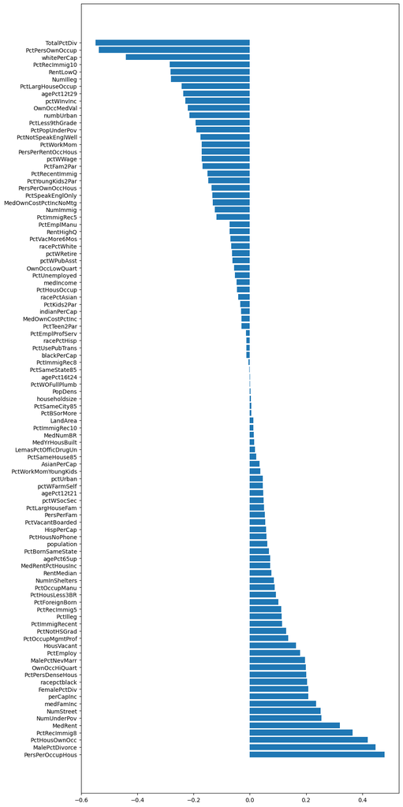

```python
fig = plt.figure(figsize=[10, 25])
plt.barh(coefs_arr[:, 0], coefs_arr[:, 1].astype(float))
plt.show()
```

### Посчитаем предсказание на тестовой выборке

```python
X_test[0]
```

```
array([0.06, 0.46, 0.02, 0.88, 0.2 , 0.2 , 0.36, 0.41, 0.22, 0.34, 0.07,
       1.  , 0.47, 0.6 , 0.12, 0.54, 0.37, 0.34, 0.51, 0.47, 0.42, 0.4 ,
       0.95, 0.21, 0.42, 0.5 , 0.03, 0.17, 0.14, 0.2 , 0.38, 0.29, 0.57,
       0.23, 0.32, 0.27, 0.49, 0.57, 0.28, 0.61, 0.62, 0.46, 0.65, 0.68,
       0.72, 0.55, 0.52, 0.57, 0.01, 0.14, 0.02, 0.25, 0.34, 0.36, 0.44,
       0.11, 0.13, 0.13, 0.15, 0.84, 0.12, 0.19, 0.19, 0.49, 0.51, 0.45,
       0.6 , 0.17, 0.45, 0.5 , 0.06, 0.74, 0.59, 0.12, 0.2 , 0.83, 0.16,
       0.18, 0.36, 0.4 , 0.41, 0.45, 0.49, 0.58, 0.5 , 0.64, 0.66, 0.19,
       0.08, 0.03, 0.19, 0.56, 0.27, 0.16, 0.65, 0.09, 0.12, 0.05, 0.  ])
```

```python
lr.predict([X_test[0]])
```

```
array([0.23358796])
```

```python
lr.predict(X_test[0].reshape(1,-1))[0]
```

```
0.23358796271798932
```

Исходя из распределения целевых значений по разным районам (см. выше), можно заключить, что при таком наборе факторов уровень преступности в данном районе будет на уровне выше среднего.

### Реальное значение для первого района в тесте

```python
y_test[0]
```

```
0.22
```

```python
abs(lr.predict([X_test[0]])[0] - y_test[0])
```

```
0.013587962717989316
```

Предсказание получилось достаточно точным

### Посчитаем среднюю абсолютную и квадратичную ошибки

```python
from sklearn.metrics import mean_absolute_error, SCORERS, mean_squared_error
```

```python
SCORERS
```

```
{'explained_variance': make_scorer(explained_variance_score),
 'r2': make_scorer(r2_score),
 'max_error': make_scorer(max_error, greater_is_better=False),
 'matthews_corrcoef': make_scorer(matthews_corrcoef),
 'neg_median_absolute_error': make_scorer(median_absolute_error, greater_is_better=False),
 'neg_mean_absolute_error': make_scorer(mean_absolute_error, greater_is_better=False),
 'neg_mean_absolute_percentage_error': make_scorer(mean_absolute_percentage_error, greater_is_better=False),
 'neg_mean_squared_error': make_scorer(mean_squared_error, greater_is_better=False),
 'neg_mean_squared_log_error': make_scorer(mean_squared_log_error, greater_is_better=False),
 'neg_root_mean_squared_error': make_scorer(mean_squared_error, greater_is_better=False, squared=False),
 'neg_mean_poisson_deviance': make_scorer(mean_poisson_deviance, greater_is_better=False),
 'neg_mean_gamma_deviance': make_scorer(mean_gamma_deviance, greater_is_better=False),
 'accuracy': make_scorer(accuracy_score),
 'top_k_accuracy': make_scorer(top_k_accuracy_score, needs_threshold=True),
 'roc_auc': make_scorer(roc_auc_score, needs_threshold=True),
 'roc_auc_ovr': make_scorer(roc_auc_score, needs_proba=True, multi_class=ovr),
 'roc_auc_ovo': make_scorer(roc_auc_score, needs_proba=True, multi_class=ovo),
 'roc_auc_ovr_weighted': make_scorer(roc_auc_score, needs_proba=True, multi_class=ovr, average=weighted),
 'roc_auc_ovo_weighted': make_scorer(roc_auc_score, needs_proba=True, multi_class=ovo, average=weighted),
 'balanced_accuracy': make_scorer(balanced_accuracy_score),
 'average_precision': make_scorer(average_precision_score, needs_threshold=True),
 'neg_log_loss': make_scorer(log_loss, greater_is_better=False, needs_proba=True),
 'neg_brier_score': make_scorer(brier_score_loss, greater_is_better=False, needs_proba=True),
 'positive_likelihood_ratio': make_scorer(positive_likelihood_ratio),
 'neg_negative_likelihood_ratio': make_scorer(negative_likelihood_ratio, greater_is_better=False),
 'adjusted_rand_score': make_scorer(adjusted_rand_score),
 'rand_score': make_scorer(rand_score),
 'homogeneity_score': make_scorer(homogeneity_score),
 'completeness_score': make_scorer(completeness_score),
 'v_measure_score': make_scorer(v_measure_score),
 'mutual_info_score': make_scorer(mutual_info_score),
 'adjusted_mutual_info_score': make_scorer(adjusted_mutual_info_score),
 'normalized_mutual_info_score': make_scorer(normalized_mutual_info_score),
 'fowlkes_mallows_score': make_scorer(fowlkes_mallows_score),
 'precision': make_scorer(precision_score, average=binary),
 'precision_macro': make_scorer(precision_score, pos_label=None, average=macro),
 'precision_micro': make_scorer(precision_score, pos_label=None, average=micro),
 'precision_samples': make_scorer(precision_score, pos_label=None, average=samples),
 'precision_weighted': make_scorer(precision_score, pos_label=None, average=weighted),
 'recall': make_scorer(recall_score, average=binary),
 'recall_macro': make_scorer(recall_score, pos_label=None, average=macro),
 'recall_micro': make_scorer(recall_score, pos_label=None, average=micro),
 'recall_samples': make_scorer(recall_score, pos_label=None, average=samples),
 'recall_weighted': make_scorer(recall_score, pos_label=None, average=weighted),
 'f1': make_scorer(f1_score, average=binary),
 'f1_macro': make_scorer(f1_score, pos_label=None, average=macro),
 'f1_micro': make_scorer(f1_score, pos_label=None, average=micro),
 'f1_samples': make_scorer(f1_score, pos_label=None, average=samples),
 'f1_weighted': make_scorer(f1_score, pos_label=None, average=weighted),
 'jaccard': make_scorer(jaccard_score, average=binary),
 'jaccard_macro': make_scorer(jaccard_score, pos_label=None, average=macro),
 'jaccard_micro': make_scorer(jaccard_score, pos_label=None, average=micro),
 'jaccard_samples': make_scorer(jaccard_score, pos_label=None, average=samples),
 'jaccard_weighted': make_scorer(jaccard_score, pos_label=None, average=weighted)}
```

```python
predicts_test = lr.predict(X_test)
predicts_train = lr.predict(X_train)
```

```python
test_mae = mean_absolute_error(y_test, predicts_test)
test_mae
```

```
0.09702507169543177
```

```python
train_mae = mean_absolute_error(y_train, predicts_train)
train_mae
```

```
0.09252593902381365
```

```python
print(abs(1-(test_mae/train_mae))*100,'%')
```

```
4.862563643326201 %
```

```python
mean_squared_error(y_test, predicts_test), mean_squared_error(y_train, predicts_train)
```

```
(0.017692614569897368, 0.016984038154523973)
```

### RMSE - больше физического смысла

```python
test_rmse = np.sqrt(mean_squared_error(y_test, predicts_test))
test_rmse
```

```
0.13301358791453363
```

```python
train_rmse = np.sqrt(mean_squared_error(y_train, predicts_train))
train_rmse
```

```
0.13032282284590052
```

```python
print(abs((1-(test_rmse/train_rmse))*100),'%')
```

```
2.0646921313351108 %
```

# Регуляризация

Как способ борьбы с переобучением.

Часто в данных мы можем наблюдать так называемую мультиколлинеарность — когда два или несколько признаков сильно коррелированы, в матрице $X$ это проявляется в виде "почти" линейной зависимости столбцов. Например, в задаче прогнозирования цены квартиры по ее параметрам "почти" линейная зависимость будет у признаков "площадь с учетом балкона" и "площадь без учета балкона". Формально для таких данных матрица $X^T X$ будет обратима, но из-за мультиколлинеарности у матрицы $X^T X$ некоторые собственные значения будут близки к нулю, а в обратной матрице $\left(X^T X\right)^{-1}$ появятся экстремально большие собственные значения, т.к. собственные значения обратной матрицы – это $\frac{1}{\lambda_i}$. Итогом такого шатания собственных значений станет нестабильная оценка параметров модели, т.е. добавление нового наблюдения в набор тренировочных данных приведёт к совершенно другому решению.

Одним из способов регуляризации является регуляризация Тихонова, которая в общем виде выглядит как добавление нового члена к среднеквадратичной ошибке: $$\large \begin{array}{rcl} \mathcal{L}\left(X, \vec{y}, \vec{w} \right) &=& \frac{1}{2n} \left\| \vec{y} - X \vec{w} \right\|_2 + \left\|\Gamma \vec{w}\right\|^2\\ \end{array}$$

В данном случае происходит предельно простая вещь. Мы "наказываем" алгоритм за слишком большие коэффициенты в векторе $\vec{w}$, прибавляя соответствующую компоненту из привычной целевой функции в виде квадратичной ошибки.

$\Gamma$ в этом случае - есть регуляризационный параметр. Чем он больше - тем сильнее регуляризация, а значит тем меньшую "свободу действий" мы даем алгоритму.

```python
ridge1 = Ridge(alpha=1.2)

ridge1.fit(X_train, y_train)

print("test", mean_absolute_error(y_test, ridge1.predict(X_test)))
print("train", mean_absolute_error(y_train, ridge1.predict(X_train)))
```

```
test 0.09604902223293273
train 0.092338160137723
```

```python
from sklearn import metrics
```

```python
test_rmse = np.sqrt(metrics.mean_squared_error(y_test, ridge1.predict(X_test)))
test_rmse
```

```
0.1323659779356818
```

```python
train_rmse = np.sqrt(metrics.mean_squared_error(y_train, ridge1.predict(X_train)))
train_rmse
```

```
0.13168740060841508
```

```python
print(abs((1-(test_rmse/train_rmse))*100),'%')
```

```
0.5152940403801765 %
```

### Усилим регуляризацию

```python
ridge2 = Ridge(alpha=10.0)

ridge2.fit(X_train, y_train)

print("test", metrics.mean_absolute_error(y_test, ridge2.predict(X_test)))
print("train", metrics.mean_absolute_error(y_train, ridge2.predict(X_train)))
```

```
test 0.09414193833124206
train 0.09465804900831709
```

Стало несколько лучше

### Наоборот сильно ослабим регуляризацию

```python
ridge3 = Ridge(alpha=0.01)

ridge3.fit(X_train, y_train)
print(mean_absolute_error(y_train, ridge3.predict(X_train)))
print(mean_absolute_error(y_test, ridge3.predict(X_test)))
```

```
0.092483329857425
0.09709408489085355
```

```python
for i in [0.1,0.5,1,1.1,1.5,2,3,4, 5]:
    ridge1 = Ridge(alpha=i)

    ridge1.fit(X_train, y_train)
    test_rmse = np.sqrt(mean_squared_error(y_test, ridge1.predict(X_test)))
    train_rmse = np.sqrt(mean_squared_error(y_train, ridge1.predict(X_train)))
    print(i,((1-(test_rmse/train_rmse))*100),'%  ',
          train_rmse, test_rmse
         )
    print()
```

```
0.1 -1.9759291375561316 %   0.13044913679806477 0.1330267193017482

0.5 -1.3516649943438486 %   0.1309660571695938 0.13273627951882755

1 -0.7338387387603618 %   0.13149939061764437 0.13246438408723046

1.1 -0.6228730287247908 %   0.1315949068220012 0.13241457600377096

1.5 -0.21086055963710493 %   0.13194884296604 0.1322270710347529

2 0.24437504146894717 %   0.13234050000674644 0.13201709285497473

3 1.0040246324970914 %   0.13300309345535644 0.13166770963508154

4 1.6166293139218135 %   0.13355246268054152 0.1313934144193834

5 2.12397109056337 %   0.1340218186722355 0.13117523398858996
```

Налицо - небольшое переобучение

# Логистическая регрессия

Основная идея линейного классификатора заключается в том, что признаковое пространство может быть разделено гиперплоскостью на два полупространства, в каждом из которых прогнозируется одно из двух значений целевого класса. Если это можно сделать без ошибок, то обучающая выборка называется линейно разделимой.

[figure not shown]

Прогнозирование не просто ответа ("+1" или "-1"), а именно вероятности отнесения к классу "+1" во многих задачах является очень важным бизнес-требованием. Например, в задаче кредитного скоринга, где традиционно применяется логистическая регрессия, часто прогнозируют вероятность невозврата кредита (). Клиентов, обратившихся за кредитом, сортируют по этой предсказанной вероятности (по убыванию), и получается скоркарта — по сути, рейтинг клиентов от плохих к хорошим. Ниже приведен игрушечный пример такой скоркарты.

[figure not shown]

Функция регуляризации для Логистической регрессии выглядит следующим образом:

[Log-loss](https://mariofilho.com/img/log_loss/0.png)

## Поступление в университет

```python
df_admit = pd.read_csv('enroll.csv', names=['gre',
                                            'gpa',
                                            'admit'])
```

```python
df_admit.head()
```

|  | gre | gpa | admit |
| --- | --- | --- | --- |
| 0 | 218.0 | 5.69 | 1.0 |
| 1 | 401.0 | 0.35 | 0.0 |
| 2 | 497.0 | 4.99 | 1.0 |
| 3 | 509.0 | 4.99 | 1.0 |
| 4 | 297.0 | 5.34 | 1.0 |

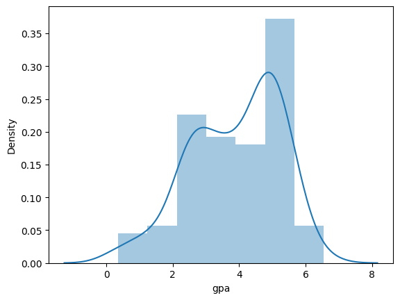

```python
sns.distplot(df_admit['gpa'], kde=True)
```

```python
df_admit.info()
```

```
<class 'pandas.core.frame.DataFrame'>
RangeIndex: 100 entries, 0 to 99
Data columns (total 3 columns):
 #   Column  Non-Null Count  Dtype
---  ------  --------------  -----
 0   gre     100 non-null    float64
 1   gpa     100 non-null    float64
 2   admit   100 non-null    float64
dtypes: float64(3)
memory usage: 2.5 KB
```

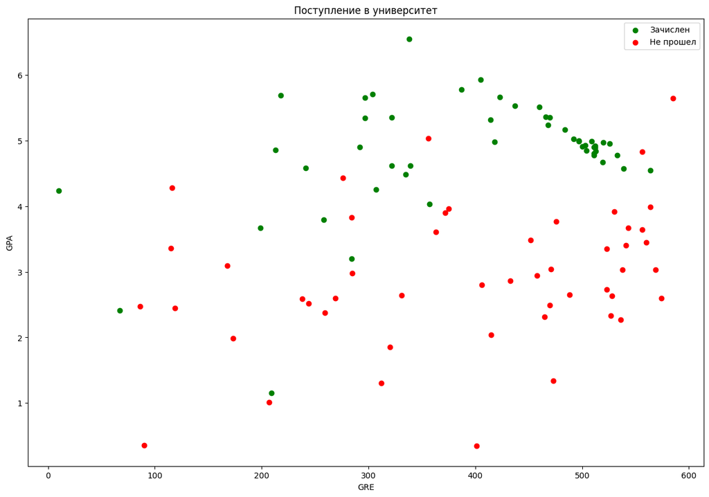

```python
plt.figure(figsize=[15, 10])
plt.scatter(df_admit[df_admit.admit == 1]['gre'],
            df_admit[df_admit.admit == 1]['gpa'],
            c='green', label='Зачислен')
plt.scatter(df_admit[df_admit.admit == 0]['gre'],
            df_admit[df_admit.admit == 0]['gpa'],
            c='red', label='Не прошел')
plt.xlabel("GRE")
plt.ylabel("GPA")
plt.title('Поступление в университет')
plt.legend();
plt.show()
```

```python
X = df_admit[['gre', 'gpa']].values
y = df_admit['admit']
```

```python
logit = LogisticRegression(random_state=17)
logit.fit(X, y)
```

```
LogisticRegression(random_state=17)
```

```python
logit.coef_
```

```
array([[-0.00427424,  1.87817315]])
```

```python
logit.intercept_
```

```
array([-5.79747442])
```

```python
def plot_boundary(clf, X_poly, y, grid_step=.01, poly_featurizer=False):
    x_min, x_max = X_poly[:, 0].min() - .1, X_poly[:, 0].max() + .1
    y_min, y_max = X_poly[:, 1].min() - .1, X_poly[:, 1].max() + .1
    xx, yy = np.meshgrid(np.arange(x_min, x_max, grid_step),
    np.arange(y_min, y_max, grid_step))
    grid_X = np.c_[xx.ravel(), yy.ravel()]

    if poly_featurizer:
        grid_X_poly = np.c_[grid_X[:, 0], grid_X[:, 1], grid_X[:, 0]**2, grid_X[:, 0]**3, grid_X[:, 1]**2, grid_X[:, 1]**3,
                            grid_X[:, 0] * grid_X[:, 1], grid_X[:, 0]**2 * grid_X[:, 1], grid_X[:, 0] * grid_X[:, 1]**2]
    else:
        grid_X_poly = grid_X.copy()

    print(grid_X_poly)
    Z = clf.predict(grid_X_poly)
    Z = Z.reshape(xx.shape)
    plt.contour(xx, yy, Z, cmap=plt.cm.Paired)
```

```
[[9.9000e+00 2.5000e-01]
 [9.9500e+00 2.5000e-01]
 [1.0000e+01 2.5000e-01]
 ...
 [5.8495e+02 6.6000e+00]
 [5.8500e+02 6.6000e+00]
 [5.8505e+02 6.6000e+00]]
```

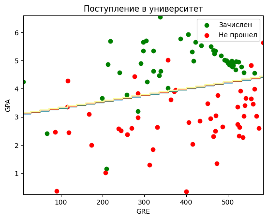

```
Доля правильных ответов классификатора на обучающей выборке: 0.89
```

```python
logit = LogisticRegression(C=1.0, n_jobs=-1, random_state=17, solver='lbfgs')
logit.fit(X, y)

plot_boundary(logit, X, y, grid_step=.05)

plt.scatter(df_admit[df_admit.admit == 1]['gre'], df_admit[df_admit.admit == 1]['gpa'], c='green', label='Зачислен')
plt.scatter(df_admit[df_admit.admit == 0]['gre'], df_admit[df_admit.admit == 0]['gpa'], c='red', label='Не прошел')
plt.xlabel("GRE")
plt.ylabel("GPA")
plt.title('Поступление в университет')
plt.legend();
plt.show()

print("Доля правильных ответов классификатора на обучающей выборке:",
round(logit.score(X, y), 3))
```

```python
logit.predict([[500, 4]])
```

```
array([0.])
```

### predict proba - предсказывает вероятности, а не конкретный класс

```python
logit.predict_proba([[500, 4]])
```

```
array([[0.60393805, 0.39606195]])
```

```python
logit.predict_proba([[300, 2]])
```

```
array([[0.96522289, 0.03477711]])
```

```python
logit.predict_proba([[500, 4]]).argmax(axis=1)
```

```
array([0])
```

```
[[9.9000e+00 2.5000e-01]
 [9.9500e+00 2.5000e-01]
 [1.0000e+01 2.5000e-01]
 ...
 [5.8495e+02 6.6000e+00]
 [5.8500e+02 6.6000e+00]
 [5.8505e+02 6.6000e+00]]
```

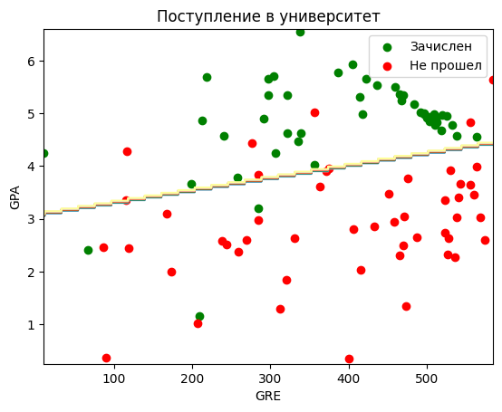

```
Доля правильных ответов классификатора на обучающей выборке: 0.89
```

```python
logit = LogisticRegression(C=1000, n_jobs=-1, random_state=17, solver='lbfgs')
logit.fit(X, y)

plot_boundary(logit, X, y, grid_step=.05)

plt.scatter(df_admit[df_admit.admit == 1]['gre'], df_admit[df_admit.admit == 1]['gpa'], c='green', label='Зачислен')
plt.scatter(df_admit[df_admit.admit == 0]['gre'], df_admit[df_admit.admit == 0]['gpa'], c='red', label='Не прошел')
plt.xlabel("GRE")
plt.ylabel("GPA")
plt.title('Поступление в университет')
plt.legend();
plt.show()

print("Доля правильных ответов классификатора на обучающей выборке:",
round(logit.score(X, y), 5))
```

```
[[9.9000e+00 2.5000e-01]
 [9.9500e+00 2.5000e-01]
 [1.0000e+01 2.5000e-01]
 ...
 [5.8495e+02 6.6000e+00]
 [5.8500e+02 6.6000e+00]
 [5.8505e+02 6.6000e+00]]
```

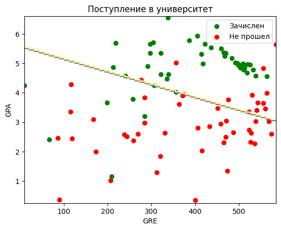

```
Доля правильных ответов классификатора на обучающей выборке: 0.8
```

```python
logit = LogisticRegression(C=1e-3, n_jobs=-1, random_state=17, solver='lbfgs')
logit.fit(X, y)

plot_boundary(logit, X, y, grid_step=.05)

plt.scatter(df_admit[df_admit.admit == 1]['gre'], df_admit[df_admit.admit == 1]['gpa'], c='green', label='Зачислен')
plt.scatter(df_admit[df_admit.admit == 0]['gre'], df_admit[df_admit.admit == 0]['gpa'], c='red', label='Не прошел')
plt.xlabel("GRE")
plt.ylabel("GPA")
plt.title('Поступление в университет')
plt.legend();
plt.show()

print("Доля правильных ответов классификатора на обучающей выборке:",
round(logit.score(X, y), 3))
```

```python
logit.coef_
```

```
array([[0.00019418, 0.04475676]])
```

Модель сильно недообучилась

## Создадим дополнительные полиномиальные признаки

Например, для $d_3$ это будут следующие признаки:

$$\large 1, x_1, x_2, x_1^2, x_1x_2, x_2^2, x_1^3, x_1^2x_2, x_1x_2^2, x_2^3$$

```python
df_mod = df_admit.copy()
```

```python
df_mod['gre2'] = df_mod['gre']**2
df_mod['gre3'] = df_mod['gre']**3
df_mod['gpa2'] = df_mod['gpa']**2
df_mod['gpa3'] = df_mod['gpa']**3
df_mod['gre_gpa'] = df_mod['gre'] * df_mod['gpa']
df_mod['gre2_gpa'] = df_mod['gre']**2 * df_mod['gpa']
df_mod['gre_gpa2'] = df_mod['gre'] * df_mod['gpa']**2
```

```python
df_mod.head()
```

|  | gre | gpa | admit | gre2 | gre3 | gpa2 | gpa3 | gre_gpa | gre2_gpa | gre_gpa2 |
| --- | --- | --- | --- | --- | --- | --- | --- | --- | --- | --- |
| 0 | 218.0 | 5.69 | 1.0 | 47524.0 | 10360232.0 | 32.3761 | 184.220009 | 1240.42 | 270411.56 | 7057.9898 |
| 1 | 401.0 | 0.35 | 0.0 | 160801.0 | 64481201.0 | 0.1225 | 0.042875 | 140.35 | 56280.35 | 49.1225 |
| 2 | 497.0 | 4.99 | 1.0 | 247009.0 | 122763473.0 | 24.9001 | 124.251499 | 2480.03 | 1232574.91 | 12375.3497 |
| 3 | 509.0 | 4.99 | 1.0 | 259081.0 | 131872229.0 | 24.9001 | 124.251499 | 2539.91 | 1292814.19 | 12674.1509 |
| 4 | 297.0 | 5.34 | 1.0 | 88209.0 | 26198073.0 | 28.5156 | 152.273304 | 1585.98 | 471036.06 | 8469.1332 |

```python
df_mod.shape
```

```
(100, 10)
```

```python
X_poly = df_mod[['gre', 'gpa', 'gre2', 'gre3', 'gpa2', 'gpa3', 'gre_gpa', 'gre2_gpa', 'gre_gpa2']].values
y_poly = np.array(df_mod['admit'])
```

```
[[9.90000000e+00 2.50000000e-01 9.80100000e+01 ... 2.47500000e+00
  2.45025000e+01 6.18750000e-01]
 [9.95000000e+00 2.50000000e-01 9.90025000e+01 ... 2.48750000e+00
  2.47506250e+01 6.21875000e-01]
 [1.00000000e+01 2.50000000e-01 1.00000000e+02 ... 2.50000000e+00
  2.50000000e+01 6.25000000e-01]
 ...
 [5.84950000e+02 6.60000000e+00 3.42166503e+05 ... 3.86067000e+03
  2.25829892e+06 2.54804220e+04]
 [5.85000000e+02 6.60000000e+00 3.42225000e+05 ... 3.86100000e+03
  2.25868500e+06 2.54826000e+04]
 [5.85050000e+02 6.60000000e+00 3.42283503e+05 ... 3.86133000e+03
  2.25907112e+06 2.54847780e+04]]
```

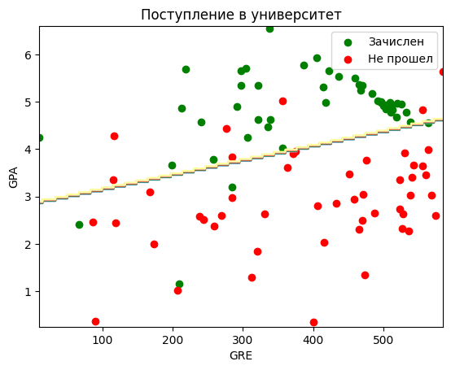

```
Доля правильных ответов классификатора на обучающей выборке: 0.89
```

```python
logit = LogisticRegression(C=1000, n_jobs=-1,
                                        random_state=17, solver='lbfgs')
logit.fit(X_poly, y_poly)

plot_boundary(logit, X_poly, y_poly, grid_step=0.05, poly_featurizer=True)

plt.scatter(df_mod[df_mod.admit == 1]['gre'],
            df_mod[df_mod.admit == 1]['gpa'], c='green', label='Зачислен')
plt.scatter(df_mod[df_mod.admit == 0]['gre'],
            df_mod[df_mod.admit == 0]['gpa'], c='red', label='Не прошел')
plt.xlabel("GRE")
plt.ylabel("GPA")
plt.title('Поступление в университет')
plt.legend()
plt.show()

print("Доля правильных ответов классификатора на обучающей выборке:",
      round(logit.score(X_poly, y_poly), 5))
```

```
[[9.90000000e+00 2.50000000e-01 9.80100000e+01 ... 2.47500000e+00
  2.45025000e+01 6.18750000e-01]
 [9.95000000e+00 2.50000000e-01 9.90025000e+01 ... 2.48750000e+00
  2.47506250e+01 6.21875000e-01]
 [1.00000000e+01 2.50000000e-01 1.00000000e+02 ... 2.50000000e+00
  2.50000000e+01 6.25000000e-01]
 ...
 [5.84950000e+02 6.60000000e+00 3.42166503e+05 ... 3.86067000e+03
  2.25829892e+06 2.54804220e+04]
 [5.85000000e+02 6.60000000e+00 3.42225000e+05 ... 3.86100000e+03
  2.25868500e+06 2.54826000e+04]
 [5.85050000e+02 6.60000000e+00 3.42283503e+05 ... 3.86133000e+03
  2.25907112e+06 2.54847780e+04]]
```

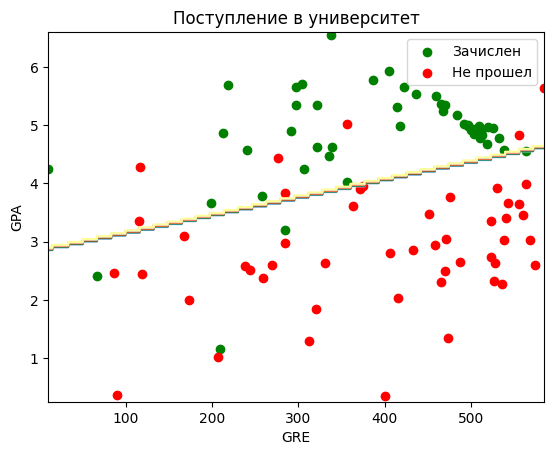

```
Доля правильных ответов классификатора на обучающей выборке: 0.89
```

```python
logit = LogisticRegression(C=100, n_jobs=-1, random_state=42, solver='lbfgs')
logit.fit(X_poly, y_poly)

plot_boundary(logit, X_poly, y_poly, grid_step=0.05, poly_featurizer=True)

plt.scatter(df_admit[df_admit.admit == 1]['gre'], df_admit[df_admit.admit == 1]['gpa'], c='green', label='Зачислен')
plt.scatter(df_admit[df_admit.admit == 0]['gre'], df_admit[df_admit.admit == 0]['gpa'], c='red', label='Не прошел')
plt.xlabel("GRE")
plt.ylabel("GPA")
plt.title('Поступление в университет')
plt.legend()
plt.show()

print("Доля правильных ответов классификатора на обучающей выборке:",
      round(logit.score(X_poly, y_poly), 3))
```

## Где логистическая регрессия не справляется

### XOR-проблема

Теперь рассмотрим пример, где линейные модели справляются хуже.

Линейные методы классификации строят все же очень простую разделяющую поверхность – гиперплоскость. Самый известный игрушечный пример, в котором классы нельзя без ошибок поделить гиперплоскостью (то есть прямой, если это 2D), получил имя "the XOR problem".

XOR – это "исключающее ИЛИ", булева функция со следующей таблицей истинности:

[figure not shown]

```python
# порождаем данные
rng = np.random.RandomState(0)
X = rng.randn(200, 2)
y = np.logical_xor(X[:, 0] > 0, X[:, 1] > 0)
```

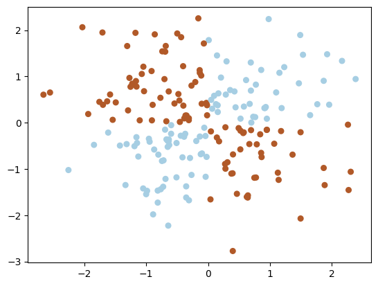

```python
plt.scatter(X[:, 0], X[:, 1], s=30, c=y, cmap=plt.cm.Paired);
```

```python
def plot_boundary(clf, X, y, plot_title):
    xx, yy = np.meshgrid(np.linspace(-3, 3, 50),
    np.linspace(-3, 3, 50))
    clf.fit(X, y)
    # plot the decision function for each datapoint on the grid
    Z = clf.predict_proba(np.vstack((xx.ravel(), yy.ravel())).T)[:, 1]
    Z = Z.reshape(xx.shape)

    image = plt.imshow(Z, interpolation='nearest',
    extent=(xx.min(), xx.max(), yy.min(), yy.max()),
    aspect='auto', origin='lower', cmap=plt.cm.PuOr_r)
    contours = plt.contour(xx, yy, Z, levels=[0], linewidths=2,
    linetypes='--')
    plt.scatter(X[:, 0], X[:, 1], s=30, c=y, cmap=plt.cm.Paired)
    plt.xticks(())
    plt.yticks(())
    plt.xlabel(r'$x_1$')
    plt.ylabel(r'$x_2$')
    plt.axis([-3, 3, -3, 3])
    plt.colorbar(image)
    plt.title(plot_title, fontsize=12);
```

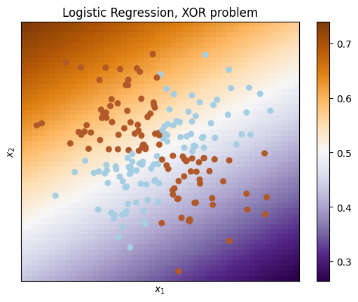

```python
plot_boundary(LogisticRegression(solver='lbfgs'), X, y,
"Logistic Regression, XOR problem")
```